# Chapter 7: Multivariate Analysis

```r
  library(here)
  library(phyloseq)
  library(SummarizedExperiment)
  library(airway) #bioconductor
  library(GGally)
  library(tidyverse)
  library(pheatmap)
  library(factoextra)
  library(ade4)
  library(MASS)
```

**Table of contents**

[1] Multivariate Analysis  
[2] Chapter Summary  
[3] What are the data? Matrices and their motivation  
[4] Dimension reduction  
[5] The new linear combinations  
[6] The PCA workflow  
[7] The inner workings of PCA: rank reduction  
[8] Plotting the observations in the principal plane  
[9] PCA as an exploratory tool: using extra information  
[10] Excercises  
[X] Misc.

**Multivariate Analysis** <sup>Return</sup>

- Datasets may have multiple variables measured on same set of subjects (multidimension on one set of data)
  - ex) Patients, samples, and organisms
  - May have characteristic biometrics: height, weight, age, clinical variables (blood pressure, blood sugar, heart rate, genetic data) for n patients
- Multivariate analysis allows investigation into connections/associations between different variables measured
  - Data usually in table data structure
    - each row = one subject
    - each column = one variable
      - In this example, variables are numeric (special case) -> use matrix to represent
      - If columns of matrix are independent from each other (no relation)
        - Can look at each column separately & use “univariate” statistics on each column -> therefore the matrix would be pointless
        - Multivariate data = columns are assumed dependent
- In multivariate data, there are patterns which depend on multiple variables
  - ex) biology of cells - proliferation rate influences gene**(s)** expression which is a simultaneous effect.
    - Study expression of 25,000 genes (columns) or many samples (rows) of patient cells = can see many genes act dependently of another (or is correlated/anti-correlated)
    - If genes study independently via “univariate” approaches = miss a lot of info
    - Connections between genes requires looking at the data as a whole
      - rows = measurements made on same observational unit
      - 25,000 columns = genes
        - problem = 25,000 variations -> need to reduce data into smaller #dimensions w/o losing information
- In this chapter - multivariate data matracies seen in high-throughput experiments
  - Focus is on Principle Component Analysis (PCA) = dimension reduction method

**Chapter Summary**<sup>Return</sup>

- **Pre-processing matracies**
  - Multivariate data analysis needs pre-processing
    - Find means, variances, and 1D histograms -> then rescale and recenter data
- **Project onto new variables**
  - Projection onto lower dimensions of high dimensional data (planes & 3D most used)
  - Low loss of information
  - PCA searches for new, informative variables which are linear combos of old ones
- **Matrix decomposition**
  - PCA needs to find decompositions of matrix (X)
    - SVD = decomposition method outputs lower rank approximations = to eigenanalysis of X<sup>t</sup>X
    - Squares of single values are equal to eigen values & variences of new variables
    - Plot these values to decide how much axes are needed to reproduce signal in data
  - 2 Eigenvalues that are close can give high scores or **PC scores which are highly unstable**
    - Need to look at screeplot of eigenvlaues & avoid separating axes of close eigenvalues
    - May need interactive 3D or 4D projections (R packages)
- **Biplot representations**
  - Space of observations is p-dimensional space (p-original variables provide coordinates)
    - Space of variables is in n-dimensions
  - Decomposition methods (singular values/eigenvalue & singular vectors/eigenvectors) -> provide new coordinates for these 2 spaces
    - Sometimes one is the dual of the other
  - Can plot projection of both observations & variables into same eigenvectors
    - Generates a biplot for interpreting PCA output
- **Projecting other group variables**
  - Can interpret PCA by redundant or contiguous data about observations

**What are the data? Matrices and their motivation**<sup>Return</sup>

- In this example, rectangular matracies represents a table w/ measurements
  - Subjects (rows) & features (columns)
- Tutles data
  - dataset used to understand principles. 3D biometric measurements on painted turtles (sex, length, width, height = 4D - compare 3 = 3D)

```r
turtles <- read.table(here("BookStuff", "data", "PaintedTurtles.txt"), header=T)
turtles[1:4,]
```

|  | sex | length | width | height |
| --- | --- | --- | --- | --- |
| 1 | f | 98 | 81 | 38 |
| 2 | f | 103 | 84 | 38 |
| 3 | f | 103 | 86 | 42 |
| 4 | f | 105 | 86 | 40 |

Last 3 columns = length measurements (mm), 1st col = factor variable sex

- Athletes data
  - Performances of 33 atheletes in 10 disciplines of decathlon: (m100, m400, m1500) times in seconds for 100m, 400m, and 1500m
  - m110 is time to finish 110 meters hurdles
  - pole is pole-vault height
  - highj and long are results for high & long jumps (in meters)
  - weight, disc, and javel are lengths in meters for throw weight, discus and javelin

```r
#Variables for first 3 atheletes
load(here("BookStuff", "data", "athletes.RData"))
unscaledAthletes <- athletes #for later use
athletes[1:3,]
```

|  | m100 | long | weight | highj | m400 | m110 | disc | pole | javel | m1500 |
| --- | --- | --- | --- | --- | --- | --- | --- | --- | --- | --- |
| 1 | 11.25 | 7.43 | 15.48 | 2.27 | 48.90 | 15.13 | 49.28 | 4.7 | 61.32 | 268.95 |
| 2 | 10.87 | 7.45 | 14.97 | 1.97 | 47.71 | 14.46 | 44.36 | 5.1 | 61.76 | 273.02 |
| 3 | 11.18 | 7.44 | 14.20 | 1.97 | 48.29 | 14.81 | 43.66 | 5.2 | 64.16 | 263.20 |

```r
load(here("BookStuff", "data", "Msig3transp.RData"))
round(Msig3transp,2)[1:5, 1:6]
```

|  | X3968 | X14831 | X13492 | X5108 | X16348 | X585 |
| --- | --- | --- | --- | --- | --- | --- |
| HEA26_EFFE_1 | -2.61 | -1.19 | -0.06 | -0.15 | 0.52 | -0.02 |
| HEA26_MEM_1 | -2.26 | -0.47 | 0.28 | 0.54 | -0.37 | 0.11 |
| HEA26_NAI_1 | -0.27 | 0.82 | 0.81 | 0.72 | -0.90 | 0.75 |
| MEL36_EFFE_1 | -2.24 | -1.08 | -0.24 | -0.18 | 0.64 | 0.01 |
| MEL36_MEM_1 | -2.68 | -0.15 | 0.25 | 0.95 | -0.20 | 0.17 |

- Bacterial species abundances data
  - Matracies of counts used in microbial ecology studies
    - Columns = different species (OTUs) - identified by numerical tags
    - Rows = labeled via samples measured
      - Integer numbers = #times each OTU observed in samples
  - Note matrix values have many 0’s == “sparse data”

```r
data("GlobalPatterns", package="phyloseq")
GPOTUs <- as.matrix(t(phyloseq::otu_table(GlobalPatterns)))
GPOTUs[1:4, 6:13]
```

```
OTU Table:          [8 taxa and 4 samples]
                     taxa are columns
        246140 143239 244960 255340 144887 141782 215972 31759
CL3          0      7      0    153      3      9      0     0
CC1          0      1      0    194      5     35      3     1
SV1          0      0      0      0      0      0      0     0
M31Fcsw      0      0      0      0      0      0      0     0
```

- mRNA reads data
  - RNA-seq transcriptome data report the #seqs reads matching each gene (or sub-gene structures - exons) in several saples (More in CH8)

```r
data("airway", package="airway")
assay(airway)[1:3, 1:4]
```

```
                SRR1039508 SRR1039509 SRR1039512 SRR1039513
ENSG00000000003        679        448        873        408
ENSG00000000005          0          0          0          0
ENSG00000000419        467        515        621        365
```

In RNA-seq (airway data), should report the genes in rows & samples in columns - this is transposed vs the other matracies loaded (rows <-> cols) * Different conventions can lead to errors so pay atttention to data

- Proteomic Profiles
  - Columns = aligned mass spectroscopy peask/molecules identified through m/z-ratios
    - Entries in matrix = measured intensities

```r
metab <- t(as.matrix(read.csv(here("BookStuff", "data", "metabolites.csv"), row.names=1)))
metab[1:4, 1:4]
```

```
         146.0985388 148.7053275 310.1505057 132.4512963
KOGCHUM1    29932.36    17055.70     1132.82    785.5129
KOGCHUM2    94067.61    74631.69    28240.85   5232.0499
KOGCHUM3   146411.33   147788.71    64950.49  10283.0037
WTGCHUM1   229912.57   384932.56   220730.39  26115.2007
```

- When a peak is not detected for a m/z score in mass spec run = 0 recorded in metab data
  - Similarly, 0’s in GPOTUs & airway data = no matching sequence reads
- Find the frequency of zeros in these data matricies

```r
colSums(assay(airway)==0)
```

```
SRR1039508 SRR1039509 SRR1039512 SRR1039513 SRR1039516 SRR1039517
     39469      39575      38403      40978      38594      38104
SRR1039520 SRR1039521
     39440      40111
```

```r
rowSums(GPOTUs)
```

```
     CL3      CC1      SV1  M31Fcsw  M11Fcsw  M31Plmr  M11Plmr  F21Plmr
  864077  1135457   697509  1543451  2076476   718943   433894   186297
 M31Tong  M11Tong LMEpi24M SLEpi20M   AQC1cm   AQC4cm   AQC7cm      NP2
 2000402   100187  2117592  1217312  1167748  2357181  1699293   523634
     NP3      NP5  TRRsed1  TRRsed2  TRRsed3     TS28     TS29    Even1
 1478965  1652754    58688   493126   279704   937466  1211071  1216137
   Even2    Even3
  971073  1078241
```

```r
rowSums(metab)
```

```
 KOGCHUM1  KOGCHUM2  KOGCHUM3  WTGCHUM1  WTGCHUM2  WTGCHUM3  KORCHUM1
 42777252  57297208  98558957 105245352  99676770 120936920 308242800
 KORCHUM2  KORCHUM3  WTRCHUM1  WTRCHUM2  WTRCHUM3
153223486 225268035 349668837 301552399 264167200
```

- 17. What are the columns of these matracies usually called?
  - The columns of these matricies are labelled w/ numbers
    - For airways data (RNA-seq) the columns indicate sample names b/c transposed
  - Coulumns should indicate features/variables of the dataset
- 17. In each of these examples, what are the rows of the matrix
  - The rows in these datasets should indicate sample ID (except RNA-seq airways which indicates genes b/c transposed)
- 17. What does a cell in a matrix represent
  - A cell represents the count/frequency something appeared for that sample (row) feature (column)
- 17. In atheletes data subset the 3rd variable (col) for the 5th athlete (row)

```r
athletes[5,3]
```

```
[1] 12.92
```

#### Low-dimensional data summaries & preparation

        $$\begin{equation}
        \hat{\rho}=
        \frac{\sum_{i=1}^n (x_i-\bar{x})(y_i-\bar{y})}
        {\sqrt{\sum_{i=1}^n (x_i-\bar{x})^2}
        \sqrt{\sum_{j=1}^n (y_j-\bar{y})^2}}
        \tag{7.1}
        \end{equation}$$
- In R - use `cor()` function to calculate correlation coefficient
  - When applied to a matrix, this calculates all 2way correlations between continous variables (more in CH9)
- 17. Compute the matrix of all correlations between the measurements from turtles data - what do you notice?

```r
cor(turtles[,-1]) #remove categorical variable to calculate other columns
```

```
          length     width    height
length 1.0000000 0.9783116 0.9646946
width  0.9783116 1.0000000 0.9605705
height 0.9646946 0.9605705 1.0000000
```

- 1. The square matrix is symmetric & all values close to 1 (diagonal values always 1)
- Beneficial to start multidimensial analysis by checking simple 1D & 2D summary statistics & make visual displays (such as below 2 questions)
- 17. Produce pairwise scatter plots & 1D histograms on the diagonal for turtles data (Use GGally package). & Guess underlying/“true dimension” of the data

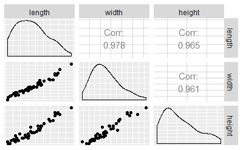

```r
ggpairs(turtles[,-1], axisLabels="none")
```

> All pairs of bivariate scatterplots for the three biometric measurements on painted turtles.

All 3 variables mostly reflect same “underlying” variable (maybe size of the turtle)

- 17. Make pairs plot on athletes data - what do you notice?

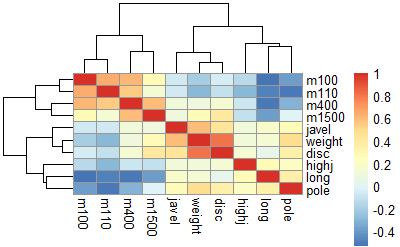

```r
pheatmap(cor(athletes), cell.width=10, cell.height=10)
```

> Heatmap of correlations between variables in the athletes data. Higher values are color coded red-orange. The hierarchical clustering shows the grouping of the related disciplines.

Shows hierarchical clustering of variables (dendogram trees) -> clusters into 3 groups (running, throwing, jumping)

#### Pre-processing data

```r
apply(turtles[,-1],2,mean)
```

```
   length     width    height
124.68750  95.43750  46.33333
```

```r
apply(turtles[,-1],2,sd)
```

```
   length     width    height
20.481602 12.675838  8.392837
```

```r
scaledTurtles <- scale(turtles[,-1])
apply(scaledTurtles,2,mean)
```

```
       length         width        height
-1.432050e-18  1.940383e-17 -2.870967e-16
```

```r
apply(scaledTurtles,2,sd)
```

```
length  width height
     1      1      1
```

```r
# How this works is explained in the next 3 code blocks
# Original data
turtles[,-1]
```

| length | width | height |
| --- | --- | --- |
| 98 | 81 | 38 |
| 103 | 84 | 38 |
| 103 | 86 | 42 |
| 105 | 86 | 40 |
| 109 | 88 | 44 |
| 123 | 92 | 50 |
| 123 | 95 | 46 |
| 133 | 99 | 51 |
| 133 | 102 | 51 |
| 133 | 102 | 51 |

[output cut: 38 more lines]

```r
# Scaled data (center = subtract col mean from data points, scale = divide datapoints by col sd)
as.data.frame(scaledTurtles)
```

| length | width | height |
| --- | --- | --- |
| -1.30299868 | -1.13897798 | -0.99291016 |
| -1.05887715 | -0.90230723 | -0.99291016 |
| -1.05887715 | -0.74452673 | -0.51631328 |
| -0.96122853 | -0.74452673 | -0.75461172 |
| -0.76593131 | -0.58674623 | -0.27801484 |
| -0.08239102 | -0.27118523 | 0.43688047 |
| -0.08239102 | -0.03451448 | -0.03971641 |
| 0.40585205 | 0.28104651 | 0.55602969 |
| 0.40585205 | 0.51771726 | 0.55602969 |
| 0.40585205 | 0.51771726 | 0.55602969 |

[output cut: 38 more lines]

```r
# Check by turning turtles into scaled dataset - subtract mean from data then divide by sd of original data (this is called centering + scaling)
Uselessturtlefunction <- function(x){
  length <- (x[,2] - mean(x[,2]))/sd(x[,2])
  width <- (x[,3] - mean(x[,3]))/sd(x[,3])
  height <- (x[,4] - mean(x[,4]))/sd(x[,4])
  combined <- data.frame(length=length, width=width, height=height)
  return(combined)
}
Uselessturtlefunction(turtles)
```

| length | width | height |
| --- | --- | --- |
| -1.30299868 | -1.13897798 | -0.99291016 |
| -1.05887715 | -0.90230723 | -0.99291016 |
| -1.05887715 | -0.74452673 | -0.51631328 |
| -0.96122853 | -0.74452673 | -0.75461172 |
| -0.76593131 | -0.58674623 | -0.27801484 |
| -0.08239102 | -0.27118523 | 0.43688047 |
| -0.08239102 | -0.03451448 | -0.03971641 |
| 0.40585205 | 0.28104651 | 0.55602969 |
| 0.40585205 | 0.51771726 | 0.55602969 |
| 0.40585205 | 0.51771726 | 0.55602969 |

[output cut: 38 more lines]

- 17. Make a scatterplot of scaled & centered width + height variables of turtle data -> color points by sex

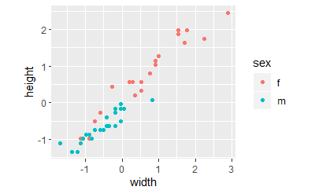

```r
data.frame(scaledTurtles, sex=turtles[,1]) %>%
  ggplot(aes(x=width, y=height, group=sex)) +
  geom_point(aes(color=sex)) + coord_fixed()
```

> Turtles data projected onto the plane defined by the width and height variables: each point colored according to sex.
- Have encountered data transformation choices in CH4 & 5
  - Used log & asinh functions -> used for variance stabiliztion (make variance of replicate measurements of one & same variable in different parts of its dynamic range more similar)
  - Standardizing transformation used here -> make scale of different variables the same (measured by mean & stv)
- May be preferable to leave variables at different scales depending on data (might be important)
  - If original scale for data is important, then leave data as is
- Some data variables have different percisions = priori (More in CH9 - weighting these variables)
- After pre-processing data -> can use data simplification via data reduction

**Dimension reduction**<sup>Return</sup>

- Many different perspectives
  - Invented to reduce 2-variable scatterplot -> single coordinate
  - Used to summarize batched psychological tests ran on same subjects
- Provides overall scores to summarize many test-variables at once
  - PCA is a **unsupervised learning technique** (so is clustering)
    - Treats all variables as having the same status
    - Not trying to predict/explain one vatiable’s value from others
      - Uses mathematical modeling to find stucture for all variables (columns)
    - Exploratory technique to map & show relations between variables + observations
- Usually suppose to use linear algebra methods but textbok tried to lower the use & focus on visualizations+data
  - Textbook uses geometrical projections -> take pts in higher-dimension spaces and projects onto lower dimensions

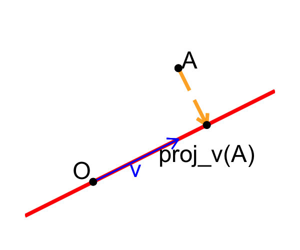

> Point A is projected onto the red line generated by the vector v. The dashed projection line is perpendicular (or orthogonal) to the red line. The intersection point of the projection line and the red line is called the orthogonal projection of A onto the red line generated by the vector v.
- PCA is a linear technique, which means it looks for linear-relationships between variables (f(ax+by)=af(x)+b(y))
  - Linear constraints decreases computational requirements (non-linear in CH9)

#### Lower-dimensional projections

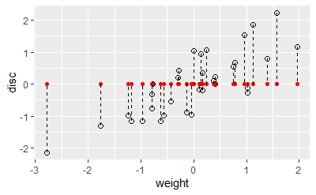

```r
# One way of projecting 2D data onto line via athletes data
athletes <- data.frame(scale(athletes))
ath_gg <- ggplot(athletes, aes(x = weight, y = disc)) + geom_point(size=2, shape=21)
ath_gg + geom_point(aes(y=0), colour="red") + geom_segment(aes(xend=weight, yend=0), linetype="dashed")
```

> Scatterplot of two variables showing the projection on the horizontal x axis (defined by y = 0 ) in red and the lines of projection appear as dashed.
- Task
  - 1. Calculate the variance of the red points in the above figure
  - 2. Make a plot showing projection lines onto y-axis & projected points
  - 3. compute the variance of the points projected onto y-axis

```r
var(athletes$weight)
```

```
[1] 1
```

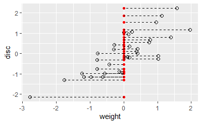

```r
ath_gg1 <- ggplot(athletes, aes(x = weight, y = disc)) + geom_point(size=2, shape=21)
ath_gg + geom_point(aes(x=0), colour="red") + geom_segment(aes(xend=0, yend=disc), linetype="dashed")
```

```r
var(athletes$disc)
```

```
[1] 1
```